# Exploring the U.S. National Oceanic and Atmospheric Administration’s (NOAA) storm database

## Synopsis

This report loads, analyzes and describes the results in terms of harmfulness (injuries and fatalities) and damages (property and crop) caused by storms and weather events tracked by NOAA - National Oceanic and Atmospheric Administration. The following questions are to be answered:

- **Which types of events are most harmful to population health?**
- **Which types of events have the greatest economic consequences?**

This report is organiZed in the following sections:

- Library loading
- Raw data download
- Data Processing
- Results

## Library loading:

Here, some of the used libraries are loaded for later use.

```r
library(data.table)
library(plyr)
library(dplyr)
library(lattice)
library(ggplot2)
```

## Raw data download

The required CSV for this analysis is available from the following web site https://d396qusza40orc.cloudfront.net/repdata%2Fdata%2FStormData.csv.bz2 and for this report the code required to download it is listed as follows.

```r
stormFileUrl <- "https://d396qusza40orc.cloudfront.net/repdata%2Fdata%2FStormData.csv.bz2"
destFileName <- "storm_data.csv.bz2"
if (!file.exists(destFileName)) download.file(stormFileUrl, destfile=destFileName, quiet=TRUE)
```

The downloaded file is saved under the name **storm_data.csv.bz2** locally to where this analysis is executed.

## Data processing

This section describes the steps necessary to load the data and select the necessary columns from the data set. After this step, then the calculations and graph plotting will be performed in order to answer the questions raised in the Synopsis section.

### Initial loading

Once the CSV with the raw data is downloaded it is time for processing the information in it.

```r
stormData <- read.csv("storm_data.csv.bz2", header=TRUE, sep=",")
```

After loading it, let’s check its dimensions

```r
dim(stormData)
```

```
## [1] 902297     37
```

The original data has 37 columns and in order to make this analysis a little bit easier to execute, only the necessary ones will be selected, as shown below:

```r
stormDataFrame <- select(stormData, EVTYPE, FATALITIES, INJURIES, PROPDMG, PROPDMGEXP, CROPDMG, CROPDMGEXP)
```

### Fatalities analysis

In this section the number of fatalities will be calculated and a bar plot will be generated to show such findings.

First of all the number of fatalities are summed and grouped by weather event type:

```r
totalFatalitiesByEvent <- with(stormDataFrame, aggregate(FATALITIES, by = list(EVTYPE), sum), na.rm=TRUE)
names(totalFatalitiesByEvent) <- c("Event", "Total")
```

Once the numbers of fatalities by event are calculated, the rows with 0 total are discarded:

```r
totalFatalitiesByEvent <- totalFatalitiesByEvent[totalFatalitiesByEvent$Total > 0, ]
```

And finally, the remaining data is sorted by the total number:

```r
totalFatalitiesByEvent <- totalFatalitiesByEvent[order(totalFatalitiesByEvent$Total, decreasing = TRUE), ]
```

Let’s observe the top 20 events:

```r
totalFatalitiesByEvent[1:20, ]
```

```
##                       Event Total
## 834                 TORNADO  5633
## 130          EXCESSIVE HEAT  1903
## 153             FLASH FLOOD   978
## 275                    HEAT   937
## 464               LIGHTNING   816
## 856               TSTM WIND   504
## 170                   FLOOD   470
## 585             RIP CURRENT   368
## 359               HIGH WIND   248
## 19                AVALANCHE   224
## 972            WINTER STORM   206
## 586            RIP CURRENTS   204
## 278               HEAT WAVE   172
## 140            EXTREME COLD   160
## 760       THUNDERSTORM WIND   133
## 310              HEAVY SNOW   127
## 141 EXTREME COLD/WIND CHILL   125
## 676             STRONG WIND   103
## 30                 BLIZZARD   101
## 350               HIGH SURF   101
```

Given the numbers calculated, a bar plot with 20 most fatal events is plotted:

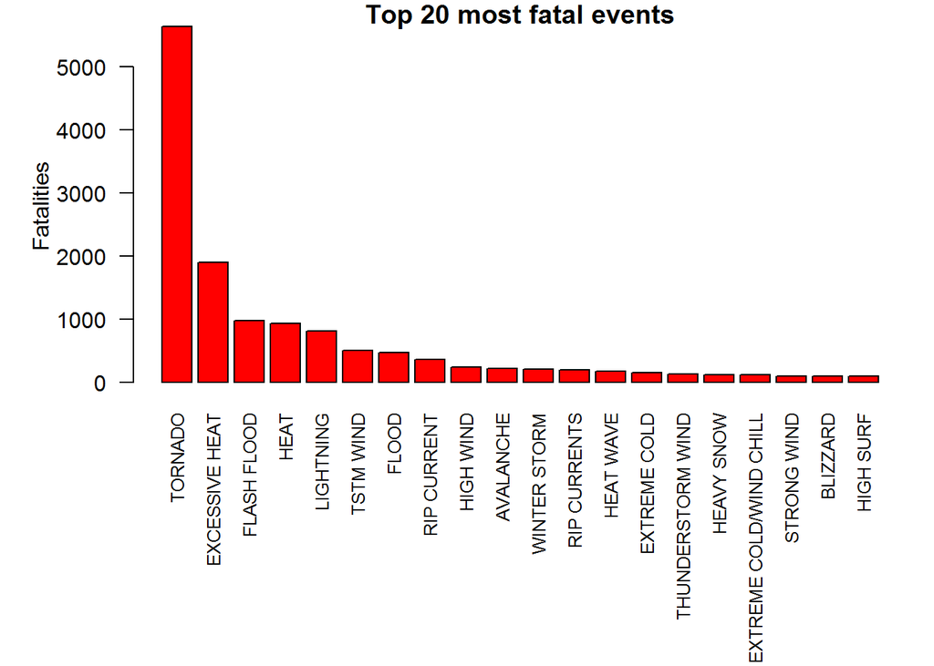

```r
par(mar = c(10.5, 5, 1, 1))
barplot(totalFatalitiesByEvent$Total[1:20], names.arg=totalFatalitiesByEvent$Event[1:20], las = 2, cex.names = 0.8, col="red", main="Top 20 most fatal events", ylab="Fatalities")
```

Given the bar plot, it is possible to notice that the most fatal events are: TORNADO, EXCESSIVE HEAT, FLASH FLOOD, HEAT, LIGHTNING, TSTM WIND, FLOOD, RIP CURRENT.

### Injuries analysis

In this section the number of injuries will be calculated and a bar plot will be generated to show such findings.

First of all the number of injuries are summed and grouped by weather event type:

```r
totalInjuriesByEvent <- with(stormDataFrame, aggregate(INJURIES, by = list(EVTYPE), sum), na.rm=TRUE)
names(totalInjuriesByEvent) <- c("Event", "Total")
```

Once the numbers of fatalities by event are calculated, the rows with 0 total are discarded:

```r
totalInjuriesByEvent <- totalInjuriesByEvent[totalInjuriesByEvent$Total > 0, ]
```

And finally, the remaining data is sorted by the total number:

```r
totalInjuriesByEvent <- totalInjuriesByEvent[order(totalInjuriesByEvent$Total, decreasing = TRUE), ]
```

Let’s observe the top 20 events:

```r
totalInjuriesByEvent[1:20, ]
```

```
##                  Event Total
## 834            TORNADO 91346
## 856          TSTM WIND  6957
## 170              FLOOD  6789
## 130     EXCESSIVE HEAT  6525
## 464          LIGHTNING  5230
## 275               HEAT  2100
## 427          ICE STORM  1975
## 153        FLASH FLOOD  1777
## 760  THUNDERSTORM WIND  1488
## 244               HAIL  1361
## 972       WINTER STORM  1321
## 411  HURRICANE/TYPHOON  1275
## 359          HIGH WIND  1137
## 310         HEAVY SNOW  1021
## 957           WILDFIRE   911
## 786 THUNDERSTORM WINDS   908
## 30            BLIZZARD   805
## 188                FOG   734
## 955   WILD/FOREST FIRE   545
## 117         DUST STORM   440
```

Given the numbers calculated, a bar plot with 20 most injurious events is plotted:

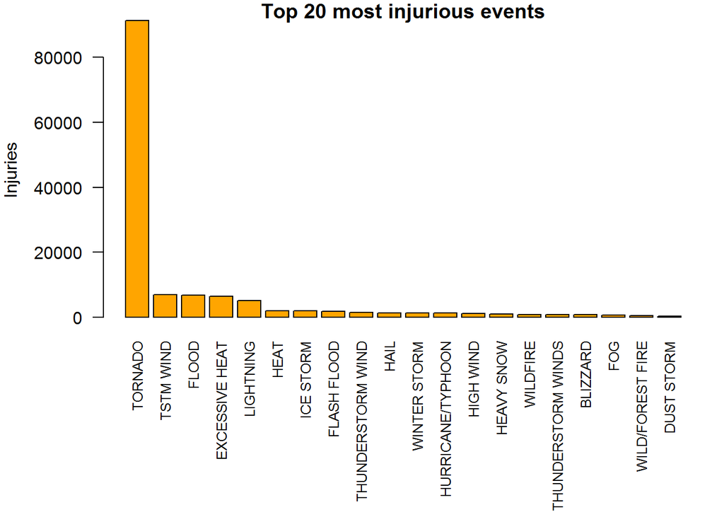

```r
par(mar = c(9.5, 5, 1, 1))
barplot(totalInjuriesByEvent$Total[1:20], names.arg=totalInjuriesByEvent$Event[1:20], las = 2, cex.names = 0.8, col="orange", main="Top 20 most injurious events")
title(ylab="Injuries", line=4)
```

Given the previous bar plot, it is possible to notice that the most injurious events are: TORNADO (majority of events) followed by TSTM WIND, FLOOD, EXCESSIVE HEAT and LIGHTNING.

### Damages analysis

In this section the damage analysis is presented and for such part both property and crop damages are considered together since the question raised seems to lead to economic consequences in a coarse fashion.

Initially, the exprssions used are prepared in order to result in the proper multiplier values:

```r
expsymbol <- c("", "+", "-", "?", 0:9, "h", "H", "k", "K", "m", "M", "b", "B")
factor <- c(rep(10^0, 4), 10^0, 10^1, 10^2, 10^3, 10^4, 10^5, 10^6, 10^7, 10^8, 10^9, 10^2, 10^2, 10^3, 10^3, 10^6, 10^6, 10^9, 10^9)
multiplier <- data.frame (expsymbol, factor)
```

Once the multipliers are in place, the calculations for property and crop damages are performed. It is worth mentioning the final figures are based in billions US$:

```r
stormDataFrame$CalculatedPropertyDmg <- stormDataFrame$PROPDMG * multiplier[match(stormDataFrame$PROPDMGEXP, multiplier$expsymbol), 2]
stormDataFrame$CalculatedCropDmg <- stormDataFrame$CROPDMG * multiplier[match(stormDataFrame$CROPDMGEXP, multiplier$expsymbol), 2]
stormDataFrame$TotalDamages <- stormDataFrame$CalculatedPropertyDmg + stormDataFrame$CalculatedCropDmg
stormDataFrame$TotalDamages <- stormDataFrame$TotalDamages / 1000000000
```

Once the numbers are generated for each event, the next step is to calculated the damages grouped by weather event type:

```r
totalDamagesByEvent <- with(stormDataFrame, aggregate(TotalDamages, by = list(EVTYPE), sum), na.rm=TRUE)
names(totalDamagesByEvent) <- c("Event", "Total")
```

Like in previous steps, the lines with 0 total are discarded and the result is ordered by the total value of damages:

```r
totalDamagesByEvent <- totalDamagesByEvent[totalDamagesByEvent$Total > 0, ]
totalDamagesByEvent <- totalDamagesByEvent[order(totalDamagesByEvent$Total, decreasing = TRUE), ]
```

Let’s observe the first 30 events with most economic impact:

```r
totalDamagesByEvent[1:30, ]
```

```
##                          Event       Total
## 170                      FLOOD 150.3196783
## 411          HURRICANE/TYPHOON  71.9137128
## 834                    TORNADO  57.3623339
## 670                STORM SURGE  43.3235410
## 244                       HAIL  18.7612220
## 153                FLASH FLOOD  18.2439911
## 95                     DROUGHT  15.0186720
## 402                  HURRICANE  14.6102290
## 590                RIVER FLOOD  10.1484045
## 427                  ICE STORM   8.9670414
## 848             TROPICAL STORM   8.3822366
## 972               WINTER STORM   6.7154413
## 359                  HIGH WIND   5.9086176
## 957                   WILDFIRE   5.0605868
```

[output cut: 16 more lines]

Using the generated figures, the supplementary bar plot is:

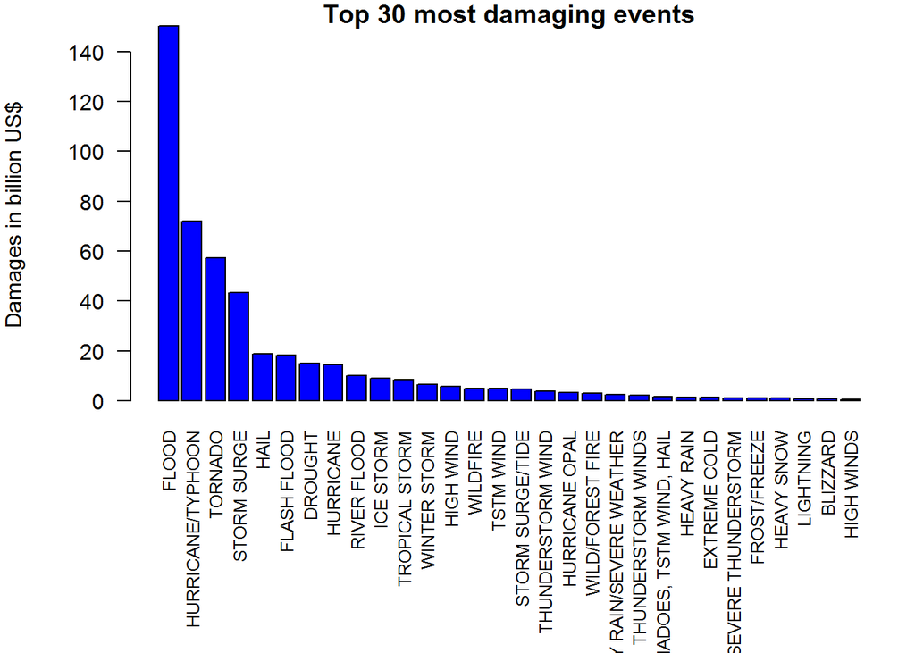

```r
par(mar = c(9.5, 5, 1, 1))
barplot(totalDamagesByEvent$Total[1:30], names.arg=totalDamagesByEvent$Event[1:30], las = 2, cex.names = 0.8, col="blue", main="Top 30 most damaging events")
title(ylab="Damages in billion US$", line=4)
```

It can be realized that the events with most economic impact are: FLOOD, HURRICANE/TYPHON, TORNADO, STORM SURGE, AHIL, FLASH FLOOD, DROUGHT, HURRICANE and RIVER FLOOD.

## Results

Given the analysis performed in the previous sections, the questions raised in the beginning of this report can be answered as follows:

- **Which types of events are most harmful to population health?**
  - The most fatal events are TORNADO, EXCESSIVE HEAT, FLASH FLOOD, HEAT, LIGHTNING, TSTM WIND, FLOOD, RIP CURRENT.
  - The most injurious events are: TORNADO (majority of events) followed by TSTM WIND, FLOOD, EXCESSIVE HEAT and LIGHTNING.
- **Which types of events have the greatest economic consequences?**
  - The events with most economic impact are: FLOOD, HURRICANE/TYPHON, TORNADO, STORM SURGE, AHIL, FLASH FLOOD, DROUGHT, HURRICANE and RIVER FLOOD.

In summary, the most harmful event is ‘TORNADO’ while in the economic perspective FLOOD is ther weather events that causes more impact.